# Chi Squared Test

## Background

Social issues are often hard to quantify but detailed surveys yield great insights if the sampling method is done correctly.

The university of Berkeley has a large dataset of surveys available for viewing at sda.berkelyey.edu ( [clickhere](http://sda.berkeley.edu/sdaweb/analysis/?dataset=gss12) ).

Their 2012 ISSP Module contains a survey question about work life balance and I am curious to see if there are any correlations between a respondents’ gender and how they answered the question.

Respondents’ gender was classified as either male or female.

The respondents were asked to respond to the statement, “It has been difficult for you to fulfil your family responsibilities because of the amount of time you spent on your job.” Their answers could be any of the following:

0: Doesn’t apply/no job 1: Several times a Week 2: Several Times a Month 3: Once or Twice 4: Never 8: Don’t Know 9: No answer

## Hypothesis

Our official question is: Does time spent working have varying impact on each genders ability to fulfilling family responsibilities. Our null and alternative hypothesis are stated below:

$H_0 : \text{The respondents' sex and their difficult to fulfil their family responsibilities are independent}$ $H_a : \text{The respondents' sex and their difficult to fulfil their family responsibilities are associated (i.e. not independent)}$

We will use $\alpha = 0.05$ as our significance level.

## Analysis

First let’s make a table of the counts for each answer by gender. I would assume that due to culture most of the female respondents will have answered 0: N/A.

```r
library(readr)
GSS2012 <- read_delim("../../Data/GSS2012.csv",
                      "\t", escape_double = FALSE, trim_ws = TRUE)
```

```r
library(mosaic)
rawdata <- GSS2012 %>%
  select(sex, JOBVSFA1)


# Filter out the IAP results
filt.data <- rawdata %>%
  filter(JOBVSFA1 != -1)

# Reformate for visibility
data <- filt.data %>%
  mutate(JobvsFam = JOBVSFA1) %>%
  select(sex, JobvsFam) %>%
  mutate(
    sex = case_when(
      sex == 1 ~ "Male",
      sex == 2 ~ "Female"
    ),
    JobvsFam = case_when(
      JobvsFam == 0 ~ "0: N/A",
      JobvsFam == 1 ~ "1: Weekly",
      JobvsFam == 2 ~ "2: Monthly",
      JobvsFam == 3 ~ "3: Once or Twice",
      JobvsFam == 4 ~ "4: Never",
      JobvsFam == 8 ~ "8: Don't Know",
      JobvsFam == 9 ~ "9: No answer"
    )
  )
```

```r
jobtable <- table(data$JobvsFam, data$sex)
jobtable2 <- t(jobtable)

jobtable
```

```
##
##                    Female Male
##   0: N/A              305  169
##   1: Weekly            53   52
##   2: Monthly           66   66
##   3: Once or Twice    111  102
##   4: Never            166  200
##   8: Don't Know         2    2
##   9: No answer          5    3
```

It does look like a largest group is female respondents stating that the question is not applicable. Let’s visualize this with a bar plot.

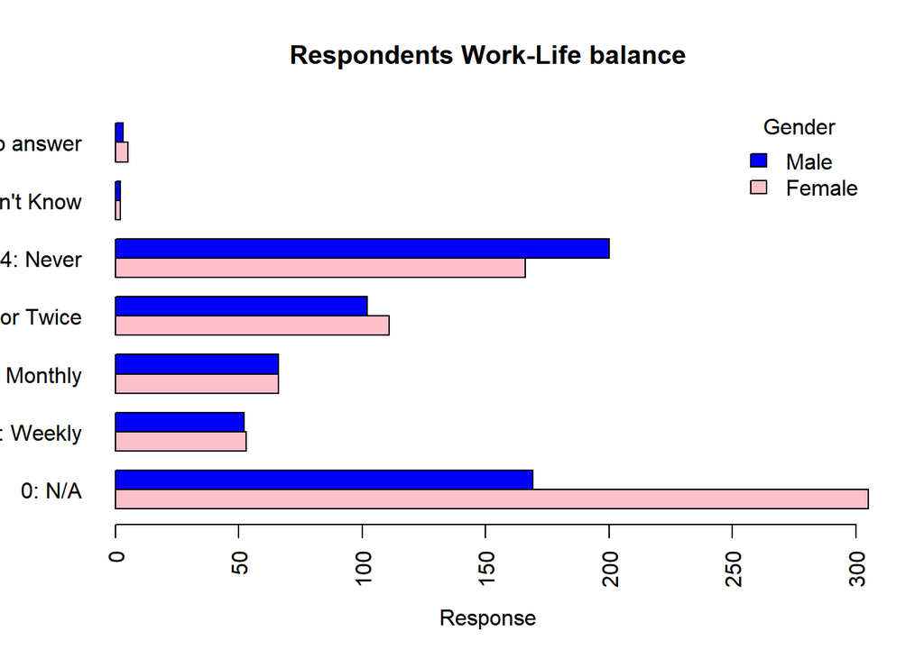

```r
barplot(jobtable2,
        beside = TRUE,
        col = c("pink","blue"),
        horiz = TRUE,
        las = 2,
        legend.text = TRUE,
        args.legend =
          list(x = "topright",
               bty = "n",
               title = "Gender"),
        xlab = "Response",
        main = "Respondents Work-Life balance")
```

Now that we’ve examined and prepared the data, I will conduct a Chi-Squared Test. This is how we’ll know if we should reject or fail to reject the null hypothesis.

```r
chi <- chisq.test(jobtable)
library(pander)
pander(chi)
```

Pearson’s Chi-squared test: `jobtable`

| Test statistic | df | P value |
| --- | --- | --- |
| 33.34 | 6 | 9.005e-06 * * * |

```r
pander(chi$expected)
```

|  | Female | Male |
| --- | --- | --- |
| **0: N/A** | 257.8 | 216.2 |
| **1: Weekly** | 57.1 | 47.9 |
| **2: Monthly** | 71.78 | 60.22 |
| **3: Once or Twice** | 115.8 | 97.18 |
| **4: Never** | 199 | 167 |
| **8: Don’t Know** | 2.175 | 1.825 |
| **9: No answer** | 4.35 | 3.65 |

These results tell us that though there are expected values that or less than 5, the average is greater than 5 and the requirements for the test have been met.

Our $p$-value (9.005e-06) is less than $\alpha$ so we reject the null hypothesis and conclude that the work-life balance and gender of respondents are associated.

In order to get a clearer picture of how these two factors are related, I have included a chart of how far our observed values where from the expected values.

```r
pander(chi$residuals)
```

|  | Female | Male |
| --- | --- | --- |
| **0: N/A** | 2.943 | -3.213 |
| **1: Weekly** | -0.5422 | 0.5919 |
| **2: Monthly** | -0.6821 | 0.7447 |
| **3: Once or Twice** | -0.4483 | 0.4895 |
| **4: Never** | -2.341 | 2.556 |
| **8: Don’t Know** | -0.1187 | 0.1296 |
| **9: No answer** | 0.3115 | -0.3401 |

The only major differences came with the observed counts of respondents answering “0:N/A” or “4: Never”.

## Interpretation

Something interesting to note is that for every question other than “0: N/A” or “9: No answer” the female respondents had less counts than expected. Male respondents likewise had more counts than expected in every area other than those same two answers. In the case of “9: No answer”, female respondents were barely above the expected values and male respondents were barely below the expected count.

It seems that that an unusually high amount of women are unemployed and thus don’t have work-life balancing issues, but at the same time there are an unusually low amount of women who answered that they never had work-life balance issues. Likewise, and unusually low amount of men were unemployed, and an unusually high amount of men said that work never interfered with their duties at home.